# AdaptiveBee test

Vinicius Almendra

Initialization code

```r
library(data.table)
library(magrittr)
library(jsonlite)
library(ggplot2)
library(lubridate)
library(caret)
library(knitr)
library(doMC)
library(randomForest)
library(scales)
library(corrplot)

registerDoMC(4) # Uses up to 4 cores for parallel computation


knitr::opts_chunk$set(echo = TRUE, comment=NA)
```

## Code to import data and save to working files (needs enough RAM space)

```r
import.file = function(filename, nrows=-1) {

  cat("Reading file", filename,"\n")
  ab0 = fread(filename, header = F, stringsAsFactors = F, verbose=T,nrows=nrows,sep="\t")

  # Extract JSON field values as lists
  cat("Extracting JSON...\n")

  js = lapply(ab0$V3, fromJSON)

  # Keeps only relevant columns
  js = lapply(js, function(x) x[c("appInstanceUid",
                                  "features",
                                  "location","vertical","os")])

  # Transforms features boolean fields
  cat("Transforming features in booleans...\n")
  js2 = lapply(js, function(x) {

    features = x$features
    features.vector = as.list(rep(TRUE,length((features))))
    names(features.vector) = features
    x$features = features.vector

    x
  })

  # Flattens list as vectors and then transform in lists again
  cat("Flattening lists....\n")
  js3 = lapply(js2, unlist)
  js4 = lapply(js3, as.list)

  # Joins everything in a single data.table
  cat("Joining...\n")
  js.df = rbindlist(js4, fill=T)

  cat("Fixing columns...\n")
  # Fixes features columns
  feat.cols = names(js.df)[grep("^features", names(js.df))]
  js.df[,(feat.cols):=lapply(.SD[,feat.cols,with=F],
                             function(x) {
                               y=as.logical(x)
                               y[is.na(y)] = FALSE
                               y
                             }
  )]


  # Convert other columns to factors
  other.cols = setdiff(names(js.df),feat.cols)
  js.df[,(other.cols):=lapply(.SD[,other.cols,with=F], as.factor)]

  # Joins back to the main table
  ab0.full = cbind(ab0[,-"V3",with=F],js.df)

  # Fixes field names
  setnames(ab0.full,"V1","timestamp")
  setnames(ab0.full,"V2","event_type")
  setnames(ab0.full,"V4","country")

  # Parses timestamp
  ab0.full[,timestamp:=as.POSIXct(timestamp)]

  # Other fields as factors
  ab0.full[, event_type := as.factor(event_type)]
  ab0.full[, country := as.factor(country)]

  ab0.full
}


files = list.files("test",pattern=".*\\d$",recursive=T,full.names=T)

for(f in files) {

  if(!file.exists(paste0(f,".rds"))) {
    db = import.file(f)
    saveRDS(db, paste0(f,".rds"))
    rm(db)
  }
  gc()
}


# Generates set without features

db.full = NULL
for(f in files) {
  cat(f,"\n")
  db = readRDS(paste0(f,".rds"))
  db[,(names(db)[grep("^features",names(db))]):=NULL]
  db[,src := f]
  db.full = rbind(db.full, db, fill=T)
  rm(db)
  print(gc())
}

# Adds an ID
db.full[,id := 1:.N]
db.full[,src := factor(src)]

saveRDS(db.full,"test_info.rds")
rm(db.full)

features.table = list()
total.nrows = 0

# Calculates features occurrence
for(f in files) {
  cat(f,"\n")
  db = readRDS(paste0(f,".rds"))

  for(n in names(db)[grepl("^features",names(db))]) {

    if(is.null(features.table[[n]]))
      features.table[[n]] = 0

    features.table[[n]] = features.table[[n]] + sum(db[[n]],
                                                    na.rm=T)
  }

  total.nrows = total.nrows + nrow(db)

  rm(db)
  print(gc())
}

features.table = unlist(features.table)

# Identify features that appear in more than a threshold
features.table = features.table[features.table > 10000]

selected.features = names(features.table)


# Generates set with only features
db.features = NULL
for(f in files) {
  cat(f,"\n")
  db = readRDS(paste0(f,".rds"))
  db = db[,intersect(names(db), selected.features),with=F]

  db.features = rbind(db.features, db, fill=T)
  rm(db)
  print(gc())
}

db.features[, id := 1:.N]
saveRDS(db.features,"test_features.rds")

# Joins everything

db.full=readRDS("test_info.rds")

db.features[,id:=NULL]
db.all = cbind(db.full,db.features)

saveRDS(db.all, "test_all.rds")

rm(db.features, db.full)
```

## Basic statistics

```r
db = readRDS("train_info.rds")

data.frame(
  `Unique users`=format(length(levels(db$appInstanceUid)),big.mark=","),
  `Unique beacons`=paste(levels(db$event_type),collapse=","),
  `First event`=min(db$timestamp),
  `Last event`=max(db$timestamp),
  `Events`=format(nrow(db),big.mark=","),
  check.names=F
)
```

```
  Unique users Unique beacons         First event          Last event
1      187,799      impbeacon 2015-05-01 00:00:01 2015-06-01 00:00:04
      Events
1 30,389,485
```

## User behavior

### Distribution of first visit

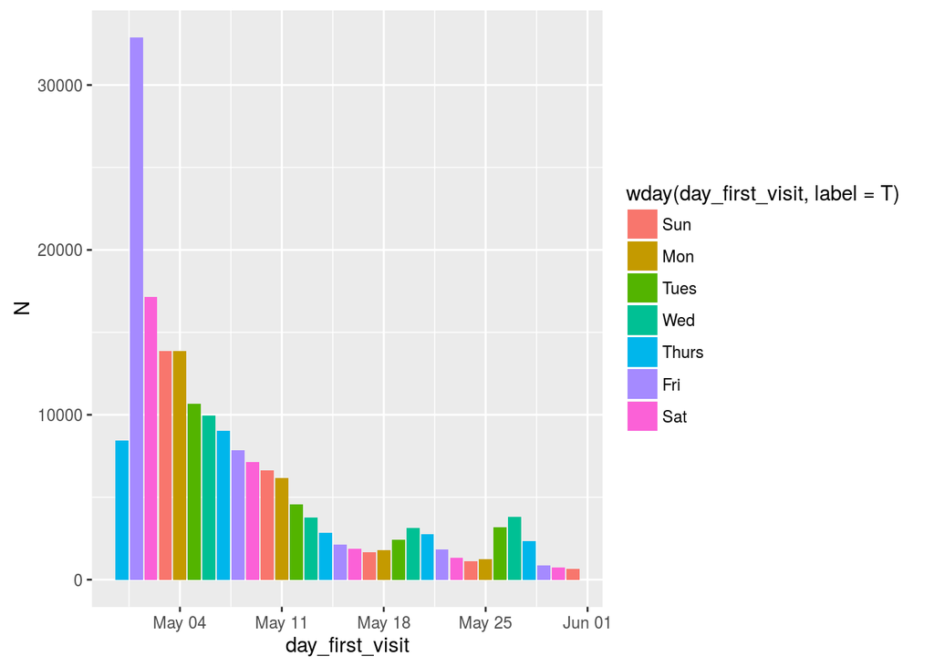

```r
setkey(db,appInstanceUid,timestamp)
fv = db[,.(day_first_visit=as.Date(min(timestamp)),
           visits=.N
           ),
           by=appInstanceUid]

ggplot(data=fv[,.N,by=day_first_visit],
       aes(x=day_first_visit, y=N,fill=wday(day_first_visit,label=T)))+
  geom_bar(stat="identity")
```

At first I see no reason for having a spike of users in the beginning of the month that slowly decreases. My first hypothesis is that in fact they are the recurring users: if they access the internet frequently, their first accesses will naturally cluster towards 0. After the first half of the month we probably see mostly new users (or users that use the browser less frequently). Let’s focus on this period:

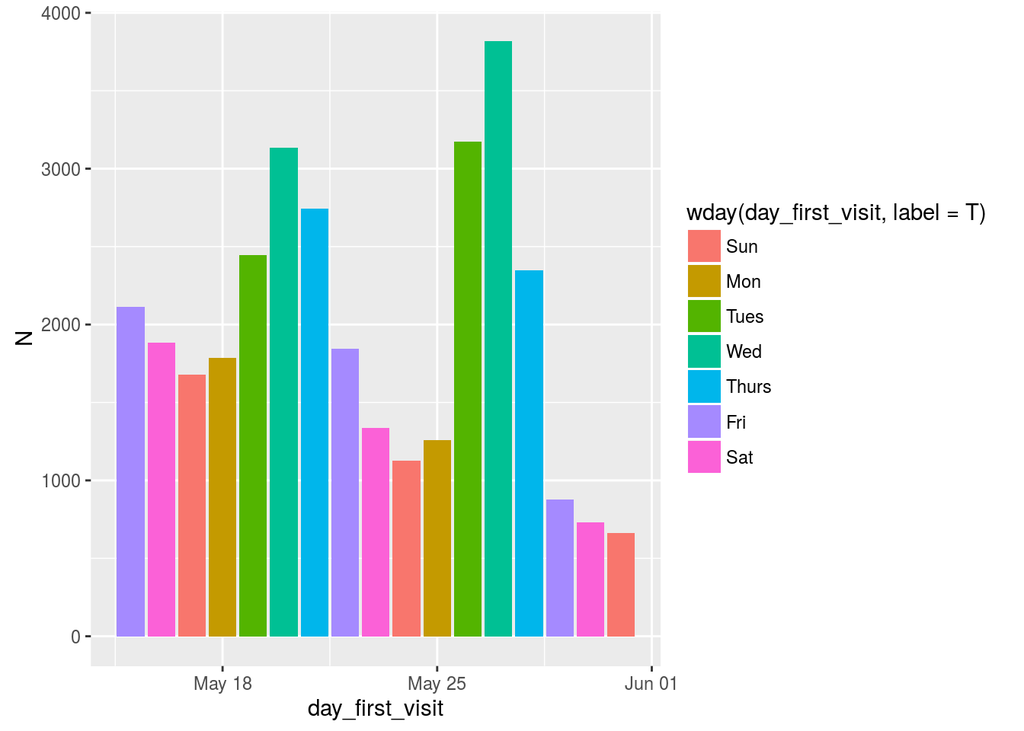

```r
ggplot(data=fv[month(day_first_visit)>=5 &
               mday(day_first_visit) >= 15,
               .N,
               by=day_first_visit],
       aes(x=day_first_visit, y=N,fill=wday(day_first_visit,label=T)))+
  geom_bar(stat="identity")
```

Let’s narrow our detailed analysis to these users, calculating extra stats:

```r
db15 = db[appInstanceUid %in% fv[month(day_first_visit)>=5 &
               mday(day_first_visit) >= 15,appInstanceUid]]

first.event = min(db15$timestamp)
setkey(db15,appInstanceUid,timestamp,location)
usr15 = db15[,.(
  first_timestamp = min(timestamp),
  date_first_visit=as.Date(min(timestamp)),
  last_timestamp = max(timestamp),
  date_last_visit=as.Date(max(timestamp)),
  visits=.N),
  by=appInstanceUid]

usr15[, day_last_visit :=
        difftime(last_timestamp,first.event,units="days") %>%
        floor %>% as.double
      ]

usr15[, day_first_visit :=
        difftime(first_timestamp,first.event,units="days") %>%
        floor %>% as.double
      ]

usr15[,lifetime.days :=
        difftime(last_timestamp, first_timestamp, units="days") %>%
        as.double
      ]
```

Let’s see the distribution of users by lifetime

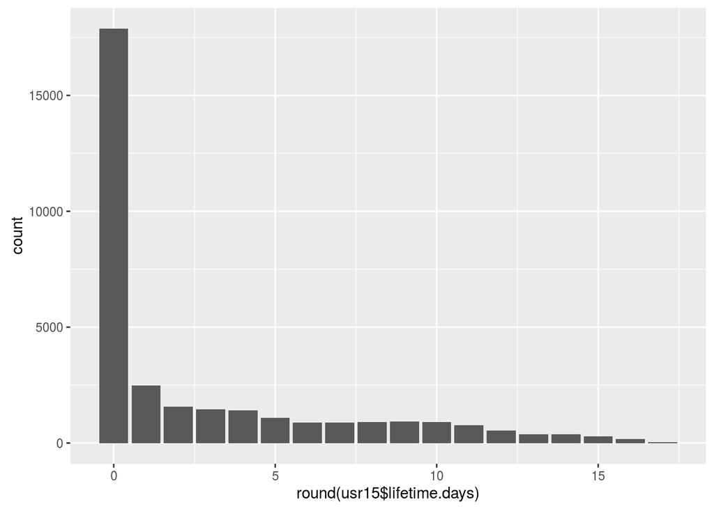

```r
ggplot(usr15, aes(x=round(usr15$lifetime.days)))+
  geom_bar()
```

Distribution has a clear discontinuity: most users that do not come back stay a very short time.

## Target definition

Since there is a clear discontinuity in the dataset, we will use it as the label for classification. The objective is to **identify which features help users stay at least one day (24h)**

```r
threshold = 1

usr15.1 = usr15[(max(day_last_visit) - day_first_visit) >  threshold]

usr15.2 = usr15.1[, returning.user := lifetime.days > threshold]
table(usr15.2$returning.user)
```

```
FALSE  TRUE
18058 13513
```

```r
nrow(usr15.2)
```

```
[1] 31571
```

Check proportion of returning users logging for first time each day

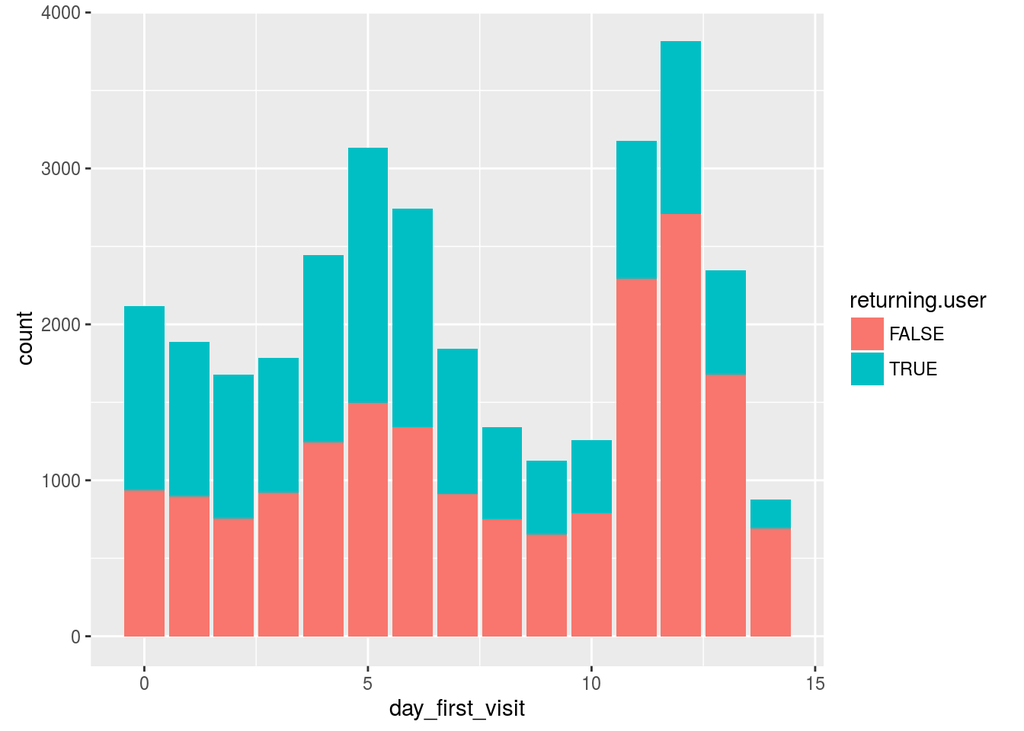

```r
ggplot(data=usr15.2, aes(x=day_first_visit,
                       fill=returning.user))+
  geom_bar()
```

Now plots only the % of users that returned

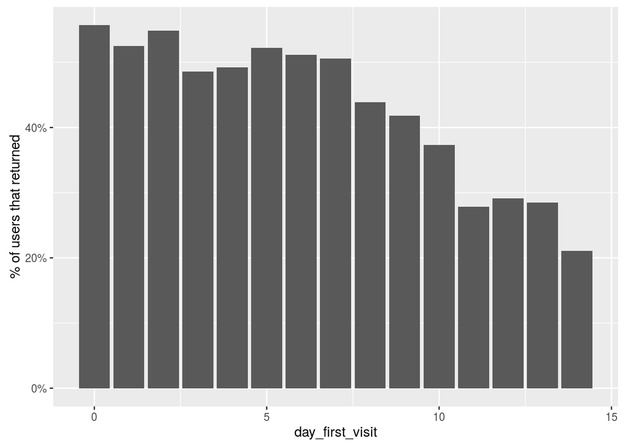

```r
ggplot(usr15.2[,.(prop=sum(returning.user)/.N),
               by=day_first_visit],
       aes(x=day_first_visit, y=prop))+
  geom_bar(stat="identity")+
  ylab("% of users that returned")+
  scale_y_continuous(labels = percent)
```

Until day 7 the proportion of returning users is quite constant. Afterwards we see a drop, probably because of some other effect (e.g. shorter timeframe to return). So to avoid “false” non-returning users, lets reduce our set from day 0 to day 7

```r
usr15.3 = usr15.2[day_first_visit <= 7]
table(usr15.3$returning.user)
```

```
FALSE  TRUE
 8496  9136
```

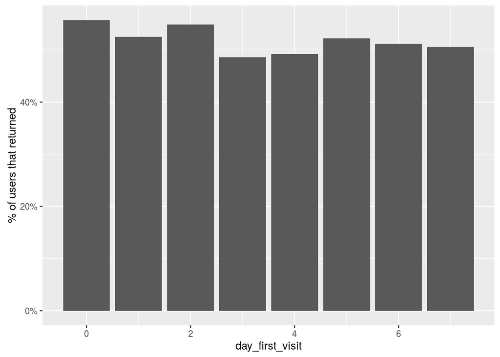

```r
ggplot(usr15.3[,.(prop=sum(returning.user)/.N),
               by=day_first_visit],
       aes(x=day_first_visit, y=prop))+
  geom_bar(stat="identity")+
  ylab("% of users that returned")+
  scale_y_continuous(labels = percent)
```

Class distribution:

```r
summary(usr15.3$returning.user)
```

```
   Mode   FALSE    TRUE    NA's
logical    8496    9136       0
```

```r
rm(db)
```

## Predicting return based on features

Extracts set of events related to the selected users

```r
db.all = readRDS("train_all.rds")

setkey(db.all,appInstanceUid)
setkey(usr15.3, appInstanceUid)
db0 = db.all[usr15.3[,.(appInstanceUid,returning.user,first_timestamp)],
            nomatch=0]

rm(db.all)

nrow(db0)
```

```
[1] 1108027
```

For each user, keeps only access on the threshold period (this avoids including in the analysis features that are usually “used” after some time)

```r
db = db0[(difftime(timestamp,first_timestamp,units="days") %>%
          as.double) <= threshold]

nrow(db)
```

```
[1] 295394
```

```r
rm(db0)
```

Aggregates feature usage by user (% of accesses that used each feature):

```r
features = c(names(db)[grep("^feature",names(db))])
db.melt = melt(db,
               id.vars=c("id","appInstanceUid",
                         "returning.user"),
               measure.vars = features,
               variable.name = "feature"
               )

db.melt.avg = db.melt[,.(value=mean(value)),
                  by=.(appInstanceUid,feature,returning.user)]


db.melt.per.label.avg = db.melt.avg[,.(value=mean(value)),
                            by=.(feature,returning.user)]
```

Visualization of feature presence (per user):

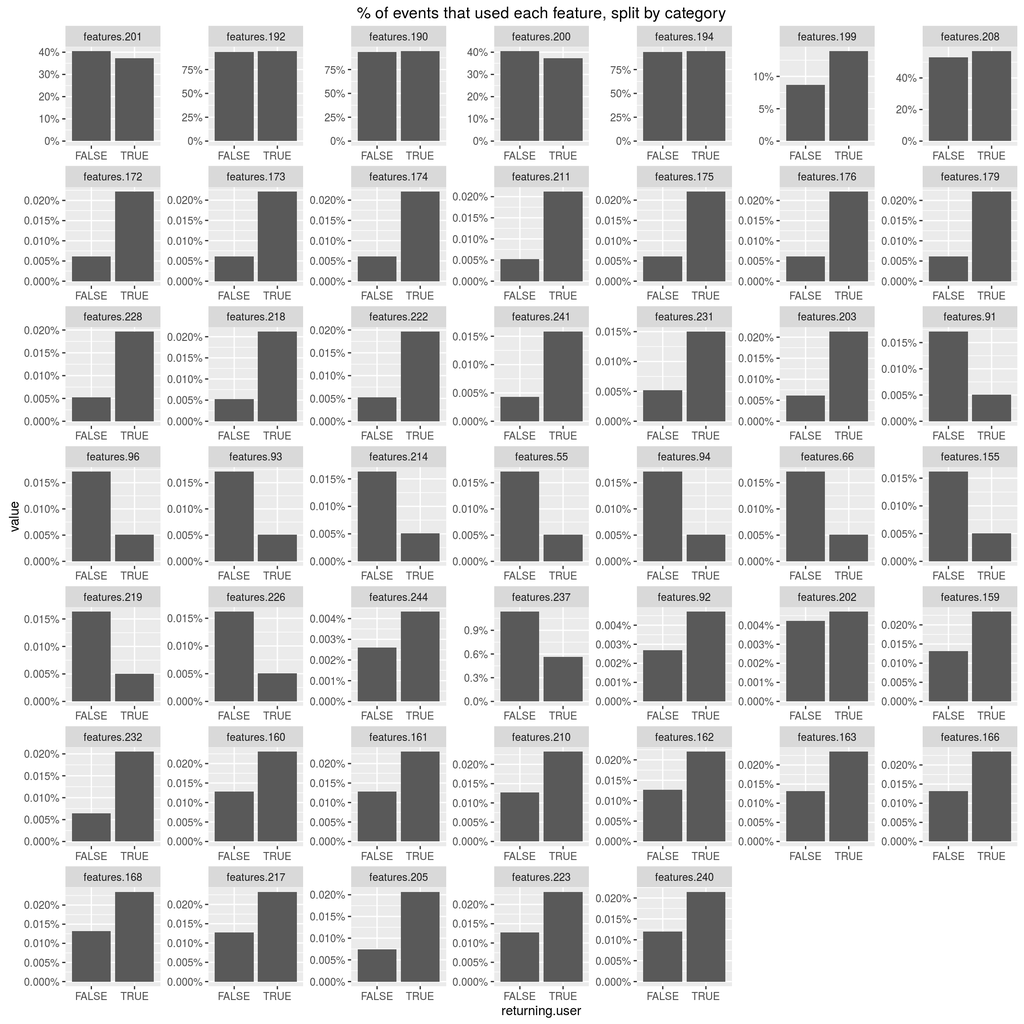

```r
ggplot(db.melt.per.label.avg, aes(x=returning.user, y=value))+
  geom_bar(stat="identity")+
  facet_wrap(~ feature, scales="free")+
  scale_y_continuous(labels=percent)+
  ggtitle("% of events that used each feature, split by category")
```

Feature presence (event counts):

```r
dcast.data.table(
  db.melt[,.(value=sum(value)),
          by=.(feature, returning.user)],
  feature ~ returning.user)
```

```
         feature FALSE   TRUE
 1: features.201 21711  55077
 2: features.192 76332 198579
 3: features.190 76332 198579
 4: features.200 21711  55077
 5: features.194 76332 198579
 6: features.199  7432  29158
 7: features.208 54621 143502
 8: features.172     6     32
 9: features.173     6     31
10: features.174     6     31
11: features.211     5     31
12: features.175     6     31
13: features.176     6     32
14: features.179     6     32
```

[output cut: 34 more lines]

Feature presence (user counts - each user is counted if has at least 1 event with respective feature):

```r
dcast.data.table(
  db.melt[,.(value=max(value)),
          by=.(appInstanceUid,feature,returning.user)],
  feature ~ returning.user,fun.aggregate = sum)
```

```
         feature FALSE TRUE
 1: features.201  5421 6654
 2: features.192  7962 8630
 3: features.190  7962 8630
 4: features.200  5421 6654
 5: features.194  7962 8630
 6: features.199  1857 3776
 7: features.208  5708 6907
 8: features.172     4   18
 9: features.173     4   18
10: features.174     4   18
11: features.211     4   18
12: features.175     4   18
13: features.176     4   18
14: features.179     4   18
```

[output cut: 34 more lines]

Builds prediction data:

```r
db.pred =
  dcast.data.table(db.melt.avg,
                   appInstanceUid+returning.user ~ feature)
db.pred[,returning.user := factor(returning.user)]

features = names(db.pred)[grep("^features",names(db.pred))]
```

```r
rm(db.melt,db.melt.per.label.avg)
```

Splits in training and test set:

```r
inTraining.idx = sample(nrow(db.pred), round(0.75*nrow(db.pred)))

training <- db.pred[inTraining.idx]
testing  <- db.pred[-inTraining.idx]
```

**Training size**: 13224 / **Test size**: 4408

Checks class distribution training

```r
table(training$returning.user) %>% prop.table
```

```
    FALSE      TRUE
0.4806413 0.5193587
```

```r
table(testing$returning.user) %>% prop.table
```

```
    FALSE      TRUE
0.4854809 0.5145191
```

Removes near-duplicate columns

```r
cormatrix=cor(training[,features,with=F])

features.to.remove = findCorrelation(cormatrix, cutoff=0.9, names=T)
features2 = setdiff(features, features.to.remove)
```

Shows correlation matrix after removal of correlated features

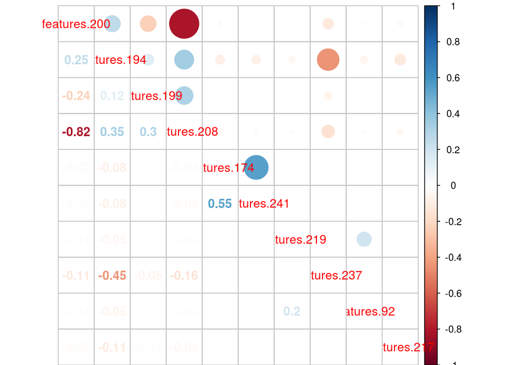

```r
cormatrix2=cor(training[,features2,with=F])

corrplot.mixed(cormatrix2)
```

Correlation is very high among some features due to the very small numbers of users that use those features, so that most users have value of 0…

## Training

Assures reproducibility across runs

```r
set.seed(1)
```

Training model with parameter optimization:

```r
fitControl <- trainControl(
  verboseIter=T,
  method = "repeatedcv",
  number = 3,
  repeats = 3)

m.rf <- train(returning.user ~ .,
            data = training[,c(features2,"returning.user"),with=F],
            method = "rf",
            trControl=fitControl,
            verbose = T)
print(m.rf)
```

```
Random Forest

13224 samples
   10 predictors
    2 classes: 'FALSE', 'TRUE'

No pre-processing
Resampling: Cross-Validated (3 fold, repeated 3 times)
Summary of sample sizes: 8816, 8817, 8815, 8815, 8817, 8816, ...
Resampling results across tuning parameters:

  mtry  Accuracy   Kappa
   2    0.5970961  0.1989582
   6    0.5835098  0.1735035
  10    0.5756200  0.1604035

Accuracy was used to select the optimal model using  the largest value.
The final value used for the model was mtry = 2.
```

Testing the model:

```r
pred = predict(m.rf, testing)
cm.rf = confusionMatrix(pred, testing$returning.user,positive="TRUE")

cm.rf
```

```
Confusion Matrix and Statistics

          Reference
Prediction FALSE TRUE
     FALSE  1474 1131
     TRUE    666 1137

               Accuracy : 0.5923
                 95% CI : (0.5777, 0.6069)
    No Information Rate : 0.5145
    P-Value [Acc > NIR] : < 2.2e-16

                  Kappa : 0.1889
 Mcnemar's Test P-Value : < 2.2e-16

            Sensitivity : 0.5013
            Specificity : 0.6888
         Pos Pred Value : 0.6306
         Neg Pred Value : 0.5658
             Prevalence : 0.5145
         Detection Rate : 0.2579
   Detection Prevalence : 0.4090
      Balanced Accuracy : 0.5951

       'Positive' Class : TRUE
```

Uses variable importance to identify best features:

```r
imp = importance(m.rf$finalModel)
good.features  = row.names(imp)[imp>2]
```

```r
print(imp[order(imp,decreasing=T),])
```

```
features.199 features.200 features.208 features.237 features.194
 165.5291845   62.6707881   53.9202647   10.8231901    9.8869633
features.217 features.174 features.241 features.219  features.92
   3.3046371    3.1616616    2.2244096    1.0656265    0.5114027
```

```r
cat(good.features,"\n")
```

```
features.200 features.194 features.199 features.208 features.174 features.241 features.237 features.217
```

Training with less variables:

```r
set.seed(1)
m.rf2 <- train(returning.user ~ .,
            data = training[,c(good.features,"returning.user"),with=F],
            method = "rf",
            trControl=fitControl,
            verbose = T)
print(m.rf2)
```

```
Random Forest

13224 samples
    8 predictors
    2 classes: 'FALSE', 'TRUE'

No pre-processing
Resampling: Cross-Validated (3 fold, repeated 3 times)
Summary of sample sizes: 8816, 8817, 8815, 8815, 8817, 8816, ...
Resampling results across tuning parameters:

  mtry  Accuracy   Kappa
  2     0.5966677  0.1987024
  5     0.5803590  0.1676335
  8     0.5762499  0.1614304

Accuracy was used to select the optimal model using  the largest value.
The final value used for the model was mtry = 2.
```

Testing the model:

```r
pred = predict(m.rf2, testing)
cm.rf2 = confusionMatrix(pred, testing$returning.user,positive="TRUE")

cm.rf2
```

```
Confusion Matrix and Statistics

          Reference
Prediction FALSE TRUE
     FALSE  1483 1138
     TRUE    657 1130

               Accuracy : 0.5928
                 95% CI : (0.5781, 0.6073)
    No Information Rate : 0.5145
    P-Value [Acc > NIR] : < 2.2e-16

                  Kappa : 0.19
 Mcnemar's Test P-Value : < 2.2e-16

            Sensitivity : 0.4982
            Specificity : 0.6930
         Pos Pred Value : 0.6323
         Neg Pred Value : 0.5658
             Prevalence : 0.5145
         Detection Rate : 0.2564
   Detection Prevalence : 0.4054
      Balanced Accuracy : 0.5956

       'Positive' Class : TRUE
```

## Final conclusions

Features at first sight are not enough to separate well both classes of users. We have a near 60% accuracy.